# point_polygon_validation

## Background

Over the last couple of years I have had the opportunity to work on projects that provide financial, demographic and indicator data from a geographical perspective so that people can find their location on a map and discover information about their locality and how they compare to their neighbors and ideally peers.

## Geographies of data

In order to associate data like debt burden, population density, and such, we needed some field that identified the locality so that it would show up on the map, ideally in the correct spot. For datasets provided by state agencies, we would typically have the name of the geographic entity and sometimes the geography type like county, city and township. For data sourced from the Census or Bureau of Labor Statistics, a unique identifier like a FIPs code would be present in the dataset.

## Points + Polygons

Choropleths consist of a shape file to show the outlines of a geography plus tabular data to provide the values for each shape which makes it easy to see the differences for an indicator across the same geography type. To get the point coordinates for a geography lots of tools and languages can generate a point `within` or a `centroid` for a polygon. Not knowing better, I thought that generating centroids for my polygons would be a safe bet and I duly joined those generated latitude and longitude coordinates to all of my tabular data by geography identifier.

## Unintended Consquences of creating data

Upon review of customers, some of the values for certain entities were not being displayed and we discovered that these geographies had a shape where the centroid didn’t actually fall inside it, like a census tract that resembled the letter C or was adjacent to a body of water. As our customers happened to reside in Michigan and California, these scenarios were a legitimate concern.

## Census + Census == Success?

After digging deeper into geospatial information provided by the Census, I learned about the existence of Gazatteer files that provide geographic attributes for all Census entities like land area, water area and Latitude and Longitude points! I had already known about the Cartographic Boundary and Tiger/Line shapefiles provided by the Census and typically used the Cartographic Boundary files for my shapes because they worked best on the Socrata platform due to lower resolution and number of vertices.

## Turns out that San Francisco is kind of a big deal

For a project that included all California cities, our client noticed that no data was showing up for San Francisco and upon inspection of the latitude and longitude provided by the Census data on a map, it very clearly was located in the Pacific ocean. Why Census? Why?

## To the [Notebook](https://github.com/aliciatb/blog/blob/master/notebooks/point_polygon_validation.ipynb)!

To regain credibility, I dug even deeper into spatial matters and was referred to a python library, geopandas by a colleague. Being a huge fan of pandas, I had no doubt that I would love geopandas. My goal was to -

1. Validata that the coordinates for all California cities fell within their expected polygon
2. Identify those coordinates that did not so they could be replaced by more accurate coordinates

```r
library(htmltools)
# jupyter nbconvert --to html ~/repos/blog/notebooks/point_polygon_validation.ipynb
includeHTML("../../notebooks/point_polygon_validation.html")
```

## Spatial Validation for Census Points & Polygons

*Latitude and Longitude coordinates provided by the Census should fall inside polygons provided by the Census, right?*

```python
%matplotlib inline

# required packages, also need run homebrew for spatial join to work!
# brew install spatialindex
#!pip3 install geopandas descartes matplotlib shapely rtree

import geopandas as gpd
import matplotlib.pyplot as plt
import pandas as pd
from shapely import geometry, wkt
from shapely.geometry import Point
```

### Load Gazetteer Locations

```
  USPS   GEOID  ANSICODE                NAME  LSAD FUNCSTAT      ALAND  \
0   CA  600135   2582926  Acalanes Ridge CDP    57        S    1193072
1   CA  600156   2629758          Acampo CDP    57        S    2428474
2   CA  600212   2407697           Acton CDP    57        S  101679341
3   CA  600296   2409663       Adelanto city    25        A  137220853
4   CA  600310   2582927            Adin CDP    57        S    8901691

   AWATER  ALAND_SQMI  AWATER_SQMI   INTPTLAT   INTPTLONG
0       0       0.461        0.000  37.904722 -122.078574
1       0       0.938        0.000  38.173529 -121.279892
2   60418      39.259        0.023  34.496070 -118.183897
3   45848      52.981        0.018  34.580902 -117.439458
4   15858       3.437        0.006  41.199312 -120.956779
```

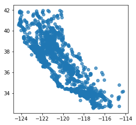

```python
# CSV converted from https://www2.census.gov/geo/docs/maps-data/data/gazetteer/2017_Gazetteer/2017_gaz_place_06.txt
census_gaz = pd.read_csv("data/2017_gaz_place_06.csv")
print(census_gaz.head())

# combine coordinates
census_gaz['Coordinates'] = list(zip(census_gaz.INTPTLONG, census_gaz.INTPTLAT))
census_gaz['Coordinates'] = census_gaz['Coordinates'].apply(Point)

# convert to Pandas Geospatial Dataframe
census_gaz_points = gpd.GeoDataFrame(census_gaz, geometry='Coordinates')

# plot the points!
census_gaz_points.plot(alpha=.7)
```

### Load Cartographic Boundary Shapefile

https://www.census.gov/geo/maps-data/data/cbf/cbf_place.html

```
  STATEFP PLACEFP   PLACENS          AFFGEOID    GEOID           NAME LSAD  \
0      06   66000  02411782  1600000US0666000  0666000      San Diego   25
1      06   48354  02411130  1600000US0648354  0648354        Modesto   25
2      06   78582  02412065  1600000US0678582  0678582  Thousand Oaks   25
3      06   17498  02410272  1600000US0617498  0617498         Cudahy   25
4      06   21712  02410406  1600000US0621712  0621712       El Cajon   25

       ALAND     AWATER                                           geometry
0  841108238  122244240  (POLYGON ((-116.93264 32.649128, -116.931919 3...
1  111280668    4768868  (POLYGON ((-121.07441 37.699985, -121.068995 3...
2  143118041     387875  (POLYGON ((-118.911435 34.171963, -118.909328 ...
3    3043278     131925  POLYGON ((-118.201898 33.970611, -118.199612 3...
4   37516313          0  POLYGON ((-117.011281 32.820275, -117.005763 3...
```

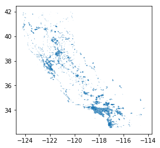

```python
# downloaded from http://www2.census.gov/geo/tiger/GENZ2017/shp/cb_2017_06_place_500k.zip
census_cb = gpd.read_file("data/cb_2017_06_place_500k/cb_2017_06_place_500k.shp")
print(census_cb.head())

# plot the polygons!
census_cb.plot()
```

### Load TIGER/Line® Shapefile

https://www.census.gov/cgi-bin/geo/shapefiles/index.php

```
  STATEFP PLACEFP   PLACENS    GEOID              NAME               NAMELSAD  \
0      06   38520  02411544  0638520         King City         King City city
1      06   86300  02412299  0686300          Woodlake          Woodlake city
2      06   80994  02412119  0680994  Twentynine Palms  Twentynine Palms city
3      06   81344  02412137  0681344            Upland            Upland city
4      06   87042  02412326  0687042           Yucaipa           Yucaipa city

  LSAD CLASSFP PCICBSA PCINECTA  MTFCC FUNCSTAT      ALAND   AWATER  \
0   25      C1       N        N  G4110        A   10090834   222052
1   25      C1       N        N  G4110        A    6305660  1178472
2   25      C1       N        N  G4110        A  152179753        0
3   25      C1       N        N  G4110        A   40432020    86983
4   25      C1       N        N  G4110        A   73279143        0

      INTPTLAT      INTPTLON  \
0  +36.2162833  -121.1319616
1  +36.4128251  -119.0995300
2  +34.1478314  -116.0659615
3  +34.1160732  -117.6599224
4  +34.0335713  -117.0429928

                                            geometry
0  (POLYGON ((-121.148837 36.208163, -121.146607 ...
1  POLYGON ((-119.134696 36.413689, -119.13468 36...
2  POLYGON ((-116.1946 34.13535, -116.194533 34.1...
3  POLYGON ((-117.704491 34.095262, -117.704433 3...
4  POLYGON ((-117.126232 34.028152, -117.126019 3...
```

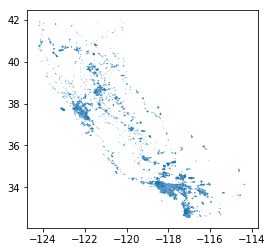

```python
# downloaded/extracted from ftp://ftp2.census.gov/geo/tiger/TIGER2018/PLACE/tl_2018_06_place.zip
census_tl = gpd.read_file("data/tl_2018_06_place/tl_2018_06_place.shp")
print(census_tl.head())

# plot the polygons!
census_tl.plot()
```

### Merge Cartographic Boundary with Gazetteer

*Note that `sjoin` will return an error referencing `libspatialindex` if you have not used homebrew to install `spatialindex` as this is a requirement of [rtree](https://pypi.org/project/Rtree/)*

```python
# coordinate reference system warning averted!
census_gaz_points.crs = census_cb.crs
cenus_gaz_points_cb = gpd.sjoin(census_gaz_points, census_cb, how="left", op='intersects')

# check for non-joined geographies
cenus_gaz_points_cb_unjoined = cenus_gaz_points_cb[cenus_gaz_points_cb.GEOID_right.isnull()]
cenus_gaz_points_cb_unjoined
```

|  | USPS | GEOID_left | ANSICODE | NAME_left | LSAD_left | FUNCSTAT | ALAND_left | AWATER_left | ALAND_SQMI | AWATER_SQMI | ... | index_right | STATEFP | PLACEFP | PLACENS | AFFGEOID | GEOID_right | NAME_right | LSAD_right | ALAND_right | AWATER_right |
| --- | --- | --- | --- | --- | --- | --- | --- | --- | --- | --- | --- | --- | --- | --- | --- | --- | --- | --- | --- | --- | --- |
| 333 | CA | 617918 | 2410291 | Daly City city | 25 | A | 19789731 | 0 | 7.641 | 0.000 | ... | NaN | NaN | NaN | NaN | NaN | NaN | NaN | NaN | NaN | NaN |
| 498 | CA | 626000 | 2410545 | Fremont city | 25 | A | 200632981 | 26291597 | 77.465 | 10.151 | ... | NaN | NaN | NaN | NaN | NaN | NaN | NaN | NaN | NaN | NaN |
| 1193 | CA | 667000 | 2411786 | San Francisco city | 25 | A | 121485107 | 479107241 | 46.906 | 184.984 | ... | NaN | NaN | NaN | NaN | NaN | NaN | NaN | NaN | NaN | NaN |
| 1296 | CA | 673262 | 2411942 | South San Francisco city | 25 | A | 23769809 | 54435146 | 9.178 | 21.018 | ... | NaN | NaN | NaN | NaN | NaN | NaN | NaN | NaN | NaN | NaN |

4 rows × 23 columns

### Merge TIGER/Line® Shapefile with Gazetteer

```python
# coordinate reference system warning averted!
census_gaz_points.crs = census_tl.crs
cenus_gaz_points_tl = gpd.sjoin(census_gaz_points, census_tl, how="left", op='intersects')

# check for non-joined geographies
cenus_gaz_points_tl_unjoined = cenus_gaz_points_tl[cenus_gaz_points_tl.GEOID_right.isnull()]
cenus_gaz_points_tl_unjoined
```

|  | USPS | GEOID_left | ANSICODE | NAME_left | LSAD_left | FUNCSTAT_left | ALAND_left | AWATER_left | ALAND_SQMI | AWATER_SQMI | ... | LSAD_right | CLASSFP | PCICBSA | PCINECTA | MTFCC | FUNCSTAT_right | ALAND_right | AWATER_right | INTPTLAT_right | INTPTLON |
| --- | --- | --- | --- | --- | --- | --- | --- | --- | --- | --- | --- | --- | --- | --- | --- | --- | --- | --- | --- | --- | --- |

0 rows × 30 columns

## What are the FIPs codes for Points not found in Cartographic Boundary shapefile?

```python
for idx,row in cenus_gaz_points_cb_unjoined.iterrows():
    geoid = row['GEOID_left']
    name = row['NAME_left']
    print(geoid,str(name))
```

```
617918 Daly City city
626000 Fremont city
667000 San Francisco city
673262 South San Francisco city
```

## Filter both shapefiles for 4 places

```python
census_cb_test = census_cb
census_cb_test = census_cb_test.query('GEOID in ("0667000","0617918","0626000","0673262")')
census_cb_test
```

|  | STATEFP | PLACEFP | PLACENS | AFFGEOID | GEOID | NAME | LSAD | ALAND | AWATER | geometry |
| --- | --- | --- | --- | --- | --- | --- | --- | --- | --- | --- |
| 297 | 06 | 26000 | 02410545 | 1600000US0626000 | 0626000 | Fremont | 25 | 200632981 | 26291597 | POLYGON ((-122.130211 37.563942, -122.124954 3... |
| 390 | 06 | 67000 | 02411786 | 1600000US0667000 | 0667000 | San Francisco | 25 | 121485107 | 479107241 | (POLYGON ((-122.332045780727 37.7877603470098,... |
| 393 | 06 | 73262 | 02411942 | 1600000US0673262 | 0673262 | South San Francisco | 25 | 23769809 | 54435146 | POLYGON ((-122.47076 37.649406, -122.469055 37... |
| 719 | 06 | 17918 | 02410291 | 1600000US0617918 | 0617918 | Daly City | 25 | 19789731 | 0 | POLYGON ((-122.50052918554 37.7008353023262, -... |

```python
census_tl_test = census_tl
census_tl_test = census_tl_test.query('GEOID in ("0667000","0617918","0626000","0673262")')
census_tl_test
```

|  | STATEFP | PLACEFP | PLACENS | GEOID | NAME | NAMELSAD | LSAD | CLASSFP | PCICBSA | PCINECTA | MTFCC | FUNCSTAT | ALAND | AWATER | INTPTLAT | INTPTLON | geometry |
| --- | --- | --- | --- | --- | --- | --- | --- | --- | --- | --- | --- | --- | --- | --- | --- | --- | --- |
| 205 | 06 | 67000 | 02411786 | 0667000 | San Francisco | San Francisco city | 25 | C1 | Y | N | G4110 | A | 121375681 | 479216672 | +37.7272391 | -123.0322294 | (POLYGON ((-122.612285 37.815224, -122.584588 ... |
| 302 | 06 | 17918 | 02410291 | 0617918 | Daly City | Daly City city | 25 | C1 | N | N | G4110 | A | 19789734 | 0 | +37.7008350 | -122.5007910 | POLYGON ((-122.500791 37.700835, -122.499925 3... |
| 304 | 06 | 73262 | 02411942 | 0673262 | South San Francisco | South San Francisco city | 25 | C1 | Y | N | G4110 | A | 23893943 | 54315250 | +37.6551037 | -122.3762341 | POLYGON ((-122.471733 37.649159, -122.471517 3... |
| 479 | 06 | 26000 | 02410545 | 0626000 | Fremont | Fremont city | 25 | C1 | N | N | G4110 | A | 200632981 | 26291597 | +37.5010483 | -122.0839341 | POLYGON ((-122.149175 37.545835, -122.135769 3... |

## Transform for Socrata Spatial Success

- Convert Polygons to Multipolygons
- Save as GEOJSON files

```python
#Handy function provided by https://github.com/geopandas/geopandas/issues/834
upcast_dispatch = {geometry.Point: geometry.MultiPoint,
                   geometry.LineString: geometry.MultiLineString,
                   geometry.Polygon: geometry.MultiPolygon}

def maybe_cast_to_multigeometry(geom):
    caster = upcast_dispatch.get(type(geom), lambda x: x[0])
    return caster([geom])

census_tl.geometry = census_tl.geometry.apply(maybe_cast_to_multigeometry)
census_cb.geometry = census_cb.geometry.apply(maybe_cast_to_multigeometry)
```

```python
# Convert to GEOJSON
census_tl.to_file("~/data/tl_2018_06_place.json", driver="GeoJSON")
census_cb.to_file("~/data/cb_2018_06_place.json", driver="GeoJSON")
```

## Visually inspect unjoined cities

- Plot point on polygon for the GEOID
- Get centroid of polygon
- Plot centroid
- Confirm spatial join between polygon and centroid

## The map

- The map layers can be toggled on and off
- If the Tiger/Line layer is turned off the orange point on the left for San Francisco does not fall within the purple Cartographic layer.
- When the Tiger/Line layer is turned on, the green shape for San Francisco encompasses the orange point in the ocean

[interactive chart not shown]

## Lessons Learned

- The Census coordinates were not *wrong* rather my reliance on simplified shapefiles led me into deep waters
- Many fine folks have created wonderful libraries and tools just waiting to verify that everything is where we think it is and if not show us where it actually is on the map!

## Resources

- Gazetteer Files - https://www.census.gov/geo/maps-data/data/gazetteer2017.html
- Cartographic Boundary shapefiles - https://www.census.gov/geo/maps-data/data/cbf/cbf_place.html
- TIGER/Line® shapefiles - https://www.census.gov/cgi-bin/geo/shapefiles/index.php
- TIGER/Line® shapefiles - https://www.census.gov/cgi-bin/geo/shapefiles/index.php
- Notebook - https://github.com/aliciatb/blog/blob/master/notebooks/point_polygon_validation.ipynb
- Data - https://github.com/aliciatb/blog/tree/master/notebooks/data